# Dasatinib_Pathway_Analysis

### *Create plots illustrating the relationship between AUC/IC50 and gene expression*

- Helps visualise the relationship between these variables.
1. Creates a boxplot and scatter plot of gene expression vs IC50.
2. Creates a boxplot and scatter plot of gene expression vs AUC.

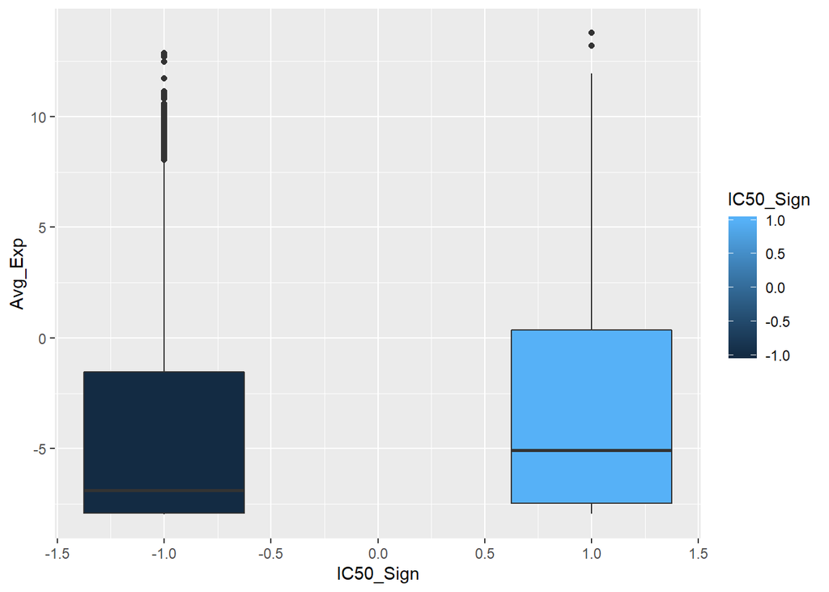

```r
# 1.
ggplot(data=tt3, mapping=aes(x=IC50_Sign,y=Avg_Exp, group=IC50_Sign, fill=IC50_Sign)) +
  geom_boxplot()
```

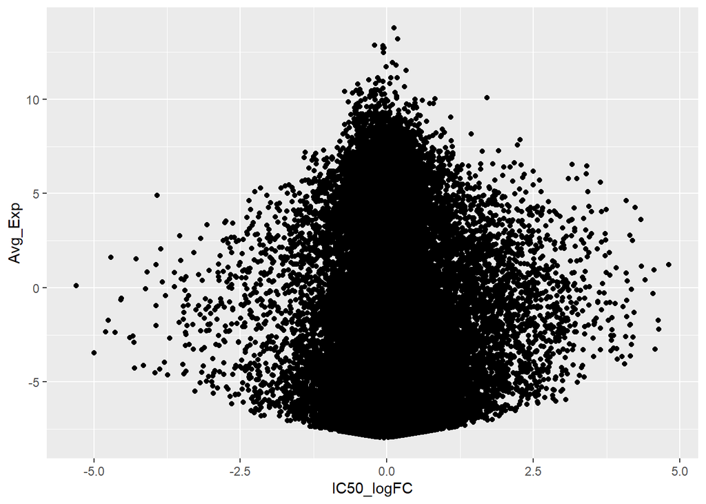

```r
ggplot(data=tt3, mapping=aes(x=IC50_logFC,y=Avg_Exp)) +geom_point()
```

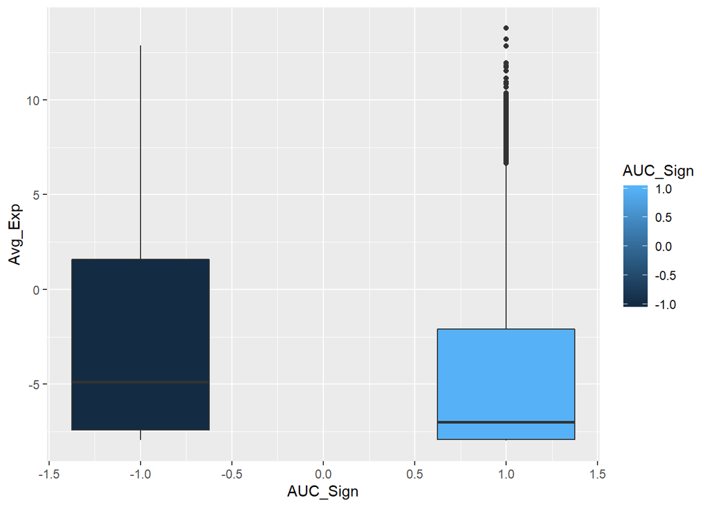

```r
# 2.
ggplot(data=tt3, mapping=aes(x=AUC_Sign,y=Avg_Exp, group=AUC_Sign, fill=AUC_Sign)) +
  geom_boxplot()
```

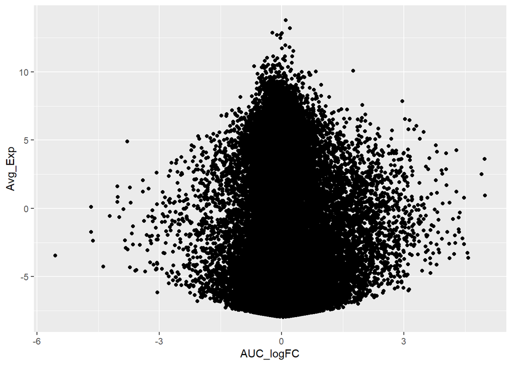

```r
ggplot(data=tt3, mapping=aes(x=AUC_logFC,y=Avg_Exp)) +geom_point()
```

## Pathway Analysis

### *Reactome PA analysis with the top 400 genes*

- Initial analysis with the “ReactomePA” package to get a general idea of what’s going on. However, this analysis is not length-corrected.
1. Loads in Entrez ID’s. These will also be used for other pathway analyses.
2. Creates a list of the top 400 genes, and uses them for pathway analysis. Plots the results, showing count and adjusted P-value.

```r
# 1.
hs <- org.Hs.eg.db

# 2.
Top400Genes <- as.character(na.omit(SigSamples$Gene_Symbol[1:400]))
Top400GenesEntrez <- AnnotationDbi::select(hs,
                            keys = Top400Genes,
                            columns = c("ENTREZID", "SYMBOL"),
                            keytype = "SYMBOL")
```

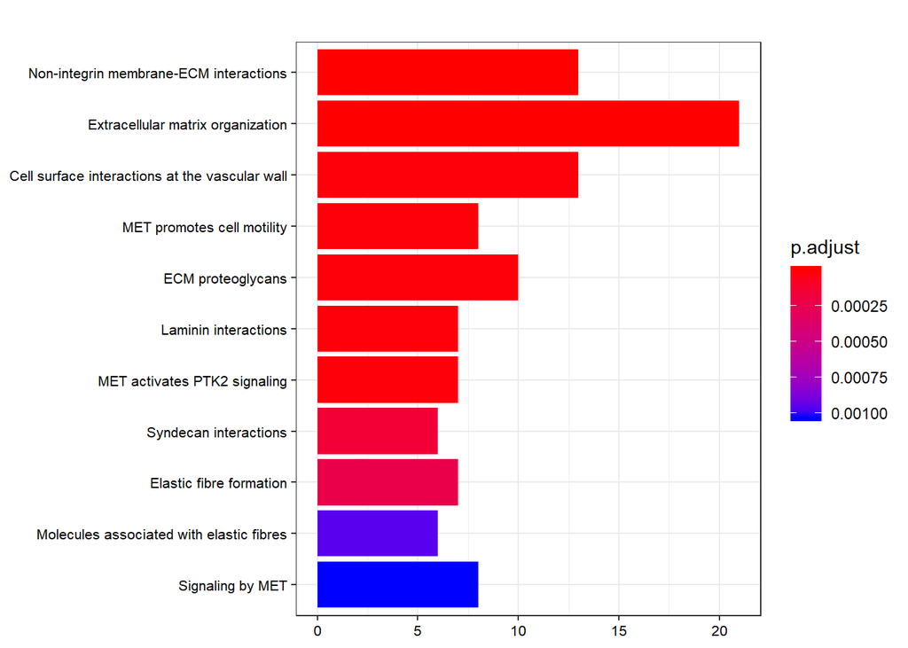

```r
dasat_rPAoverrep <- enrichPathway(gene=Top400GenesEntrez$ENTREZID, organism = "human", pvalueCutoff = 10, readable=T)
barplot(dasat_rPAoverrep, showCategory=11, font.size=8)
```

```
## wrong orderBy parameter; set to default `orderBy = "x"`
```

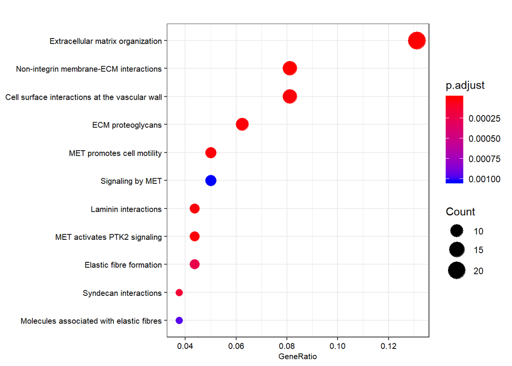

```r
dotplot(dasat_rPAoverrep, showCategory=11, font.size=8)
```